# Activity: Street or Road?

Willem Krantz

## Load in the data

```r
DataSet<- read_csv("https://mdbeckman.github.io/dcSupplement/data/street-addresses.csv")
```

## Recreate Solved Example using `sample(50)`

```r
Addresses<-read_csv("https://mdbeckman.github.io/dcSupplement/data/street-addresses.csv")
```

## Recreate Soved Example using the entire `Address` data set

#### Additional Question: How many addresses are a PO BOX (including NCSU BOX)?

| count |
| --- |
| 33 |

#### Part 1: Explain (in english) each line of the following code chunk

```r
LeftOvers <-Addresses %>%
  filter( !grepl(pattern, address),
          !grepl("\\sAPT|UNIT\\s[\\d]+$", address),
          !grepl(" BOX ", address)
          )
```

```
Error in `filter()`:
ℹ In argument: `!grepl(pattern, address)`.
Caused by error:
! object 'pattern' not found
Backtrace:
 1. Addresses %>% ...
 9. base::grepl(pattern, address)
```

My answer here……. line one names the new table line 2 defines it as leftovers line 3 pulls from our addresses line 4 filters by pattern specifically apartment, unit, po box and address.

#### Part 2: Implement your method on the entire `Addresses` data set. Explain how your code works line by line.

My answer here……. Same as the prior code the pattern defines the 3 endings we are looking for. LeftOvers becomes the new data set title. The filter function allows us to filter out answers so that we are only left with that we want which are endings without ST,RD, or ROAD

```r
leftovers2<-Addresses%>%
  filter(!grepl(NewPattern,address)),
```

```
Error: unexpected ',' in:
"leftovers2<-Addresses%>%
  filter(!grepl(NewPattern,address)),"
```

#### Additional Question 2: Present your result by using ggplot to a bar chart in descending order of popularity for the street name endings you found previously.

Note: make sure your order street names according to popularity, not alphabetically.

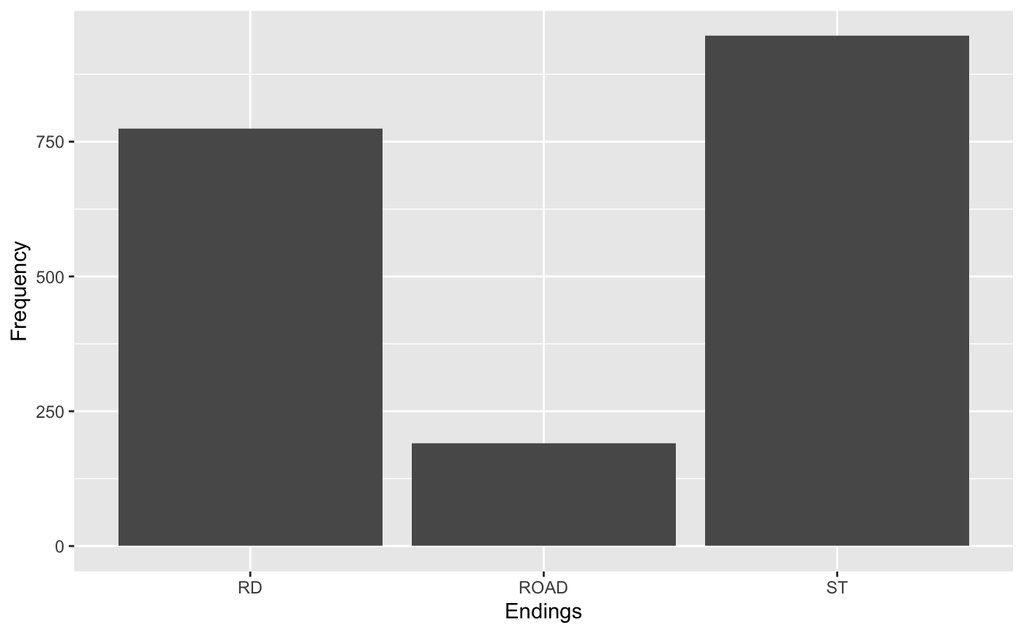

[figure not shown]

#### Additional Question 3: Comment on any patterns you see

My answer here…….

RD and ROAD have the same meaning yet RD is used far more often which makes sense as RD takes up less space on a sign, but again means the same thing as ROAD.